# Statistical inference with the GSS data

kimnewzealand

29 June 2017

## Setup

### Load packages

```r
library(ggplot2)
library(dplyr)
library(statsr)
library(knitr)
```

### Load data

```r
setwd("~/InfStatsProject")
load("gss.Rdata")
```

## Part 1: Data

**BACKGROUND**

As per the reference documentation, http://gss.norc.org/ the data is an extract of the General Social Survey (GSS) Cumulative File 1972-2012 with the following modifications:

- All missing values have been removed from this data.
- Factor variables have been created on categorical variables.

**SAMPLING METHOD**

The sampling method is a simple random sample, selected randomly by household address with each having an equal probably of selection. The within sample responses can be assumed to be independent and less than 10% of the US population, which is in millions.

We can take a look at the actual number of respondents each year by looking at a summary table of the *year* variable against the calculated response rate (%).

```r
yearsum <- summary(gss %>%
          group_by(year) %>%
          summarise(response.rate=n()/5000*100))
kable(yearsum, caption="Summary of Response Rate", align="c")
```

Summary of Response Rate

|  | year | response.rate |
| --- | --- | --- |
|  | Min. :1972 | Min. :27.44 |
|  | 1st Qu.:1980 | 1st Qu.:29.98 |
|  | Median :1988 | Median :31.98 |
|  | Mean :1989 | Mean :39.35 |
|  | 3rd Qu.:1998 | 3rd Qu.:40.88 |
|  | Max. :2012 | Max. :90.20 |

From this table summary the sample sizes varies from year to year. Since there are less responses than the 5,000 selected each year, there could be some voluntary or non-response bias in the survey.

The sample may be generalizable to the population if the random samples are a representation of the population.

This is an observational study, not an experimental study with random assignment, so it should not be used to derive causal statements.

**SUMMARY OF DATASET**

The gss.Rdata dataset contains 57061 observations and 114 variables in a long format.

The identifier variable for each survey is:  
- *caseid: case identification number*

## Part 2: Research question

We will explore any relationships confidence in the press and the news reported in media channels, such as newspapers and TV, in recent years.

This is topical at the moment with the recent elections in the US, France and the UK, where news is also being distributed through new channels, such as social media channels.

## Part 3: Exploratory data analysis

Let’s take a look at the relationship between the two variables:  
- *year*: GSS year for this respondent  
- *conpress*: confidence in press

```r
# Produce summary statistics of the year and conpress variables
kable(t(as.matrix(summary(gss$year))),format='html')
```

| Min. | 1st Qu. | Median | Mean | 3rd Qu. | Max. |
| --- | --- | --- | --- | --- | --- |
| 1972 | 1983 | 1993 | 1992 | 2002 | 2012 |

```r
kable(t(as.matrix(summary(gss$conpress))),format='html')
```

| A Great Deal | Only Some | Hardly Any | NA’s |
| --- | --- | --- | --- |
| 6128 | 20346 | 11465 | 19122 |

Although the *year* is an integer we will treat it as a categorical variable. The *conpress* is a factor with 3 levels and 34% NA’s. As mentioned, all missing values have been recoded to missing (NA) in the dataset.

With two categorical variables so we will view a stacked barplot with percentages to view the relative values between years.

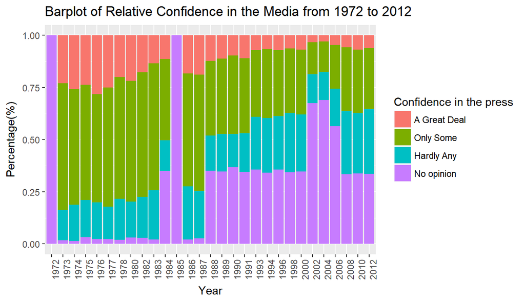

```r
# Get levels and recode NA to "No opinion" as this variable has NA documented as such.
levels <- levels(gss$conpress)
levels[length(gss$conpress) + 1] <- "No opinion"

# Refactorconpress to include "No opinion" as a factor level
# and replace NA with "None"
gss$conpress <- factor(gss$conpress, levels = levels)
gss$conpress[is.na(gss$conpress)] <- "No opinion"

# Calculate a relative frequency table with table and prop.table and table functions
yearpress<- prop.table(table(gss$year,gss$conpress,useNA = "ifany"))
yearpress <- as.data.frame(yearpress)
names(yearpress) <- c("year","confidence","percentage")

# Plot using ggplot, plot a barplot
g <- ggplot(yearpress,aes(year,percentage))
g + geom_bar(stat="identity",position = position_fill(),aes(fill=confidence)) +
  theme(axis.text.x = element_text(angle=90)) +
  labs(title="Barplot of Relative Confidence in the Media from 1972 to 2012", x = "Year", y = "Percentage(%)") +
  scale_fill_discrete("Confidence in the press")
```

Based on this summary it appears that the category “A Great deal” and “Only some” have decreased and that the category of “Hardly any” and “No opinion”, has increased as a proportion over time.

We can also take a look at the confidence categories as a boxplot.

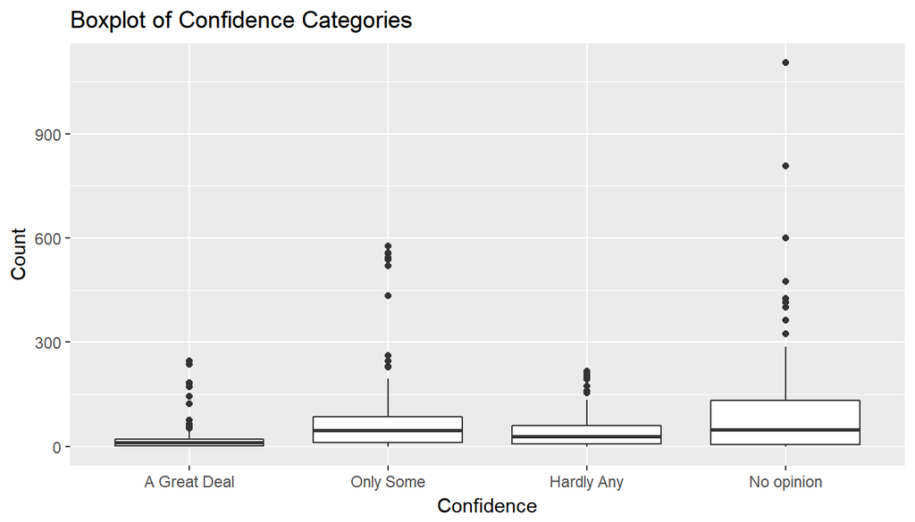

```r
# Calculate a frequency table for year and conpress and news
yearpresstable <- table(gss$year,gss$conpress,gss$news)
yearpresstable <- as.data.frame(yearpresstable)
names(yearpresstable) <- c("year","confidence","newspaper","count")

# Plot boxplot of confidence categories
g <- ggplot(yearpresstable,aes(confidence,count))
g + geom_boxplot() +
  labs(title="Boxplot of Confidence Categories", x = "Confidence", y = "Count")
```

The variability is not constant across the year groups, and as we noted previously from the response rates, these year groups different sample sizes. By not meeting this constant variability condition, we would not be able to test means between the year groups using ANOVA.

Next let’s review the media related variables visually using plots:  
- *news*: How often does R read newspaper  
- *tvhours*: Hours per day watching TV

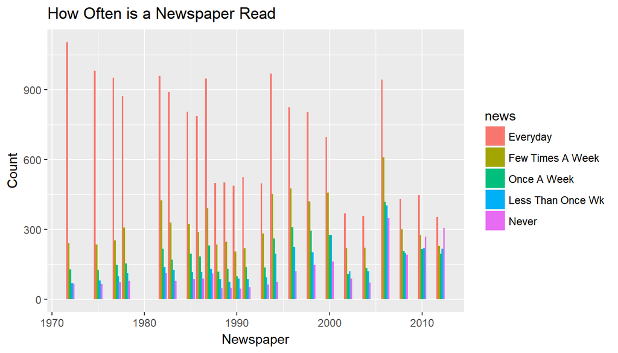

```r
# View the newspaper reading trends variable over time, removing missing value NA's from the plot
g <- ggplot(gss[!is.na(gss$news), ],aes(year))
g + geom_bar(aes(fill=news),position="dodge",na.rm=FALSE) +
  labs(title="How Often is a Newspaper Read",x= "Newspaper",y="Count")
```

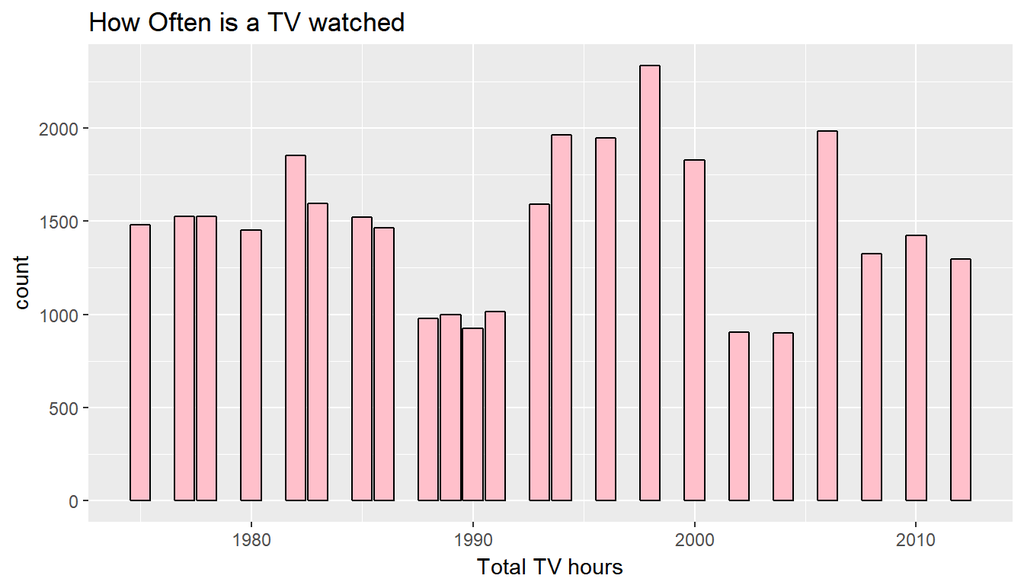

```r
# View the  tvhours trends over time, removing any missing value NAs
g <- ggplot(gss[!is.na(gss$tvhours), ],aes(year))
g + geom_bar(aes(fill=tvhours),fill="pink",colour="black",position="dodge") +
     labs(title="How Often is a TV watched",x= "Total TV hours",Y="Count")
```

## Part 4: Inference

**INFERENCE METHOD**

We can look to perform a test using proportions to see if there is a relationship between confidence in the press *conpress* and how often a newspaper is read *news* for the most recent surveys, 2010 and 2012. As discussed, we are unable to test between group years due to non-constant variability of *conpress*.

Since the we are testing a categorical variables *conpress* and *news* both with more than two levels, we will use the chi-squared test for independence method.

We will not calculate a confidence interval as this calculation estimates one parameter, and here we have multiple levels.

**HYPOTHESIS TEST**

First set the hypothesis test:

The null hypothesis $H_0$ : that the two variables *conpress* and *news* are independent for 2010 and for 2012.

The alternative hypothesis $H_A$ : that the two variables *conpress* and *news* are dependent for 2010 and for 2012.

```r
# Summarise 2010 data in a contingency table to perform the test
yearpresstable2010 <- yearpresstable %>%
  filter(year=="2010") %>%
  select(-year)
n2010 <- sum(yearpresstable2010$count)
yearpresstable2010 <- with(yearpresstable2010,tapply(count,list(confidence,newspaper),mean))
df <- (dim(yearpresstable2010)[1]-1 )*(dim(yearpresstable2010)[2]-1)
kable(yearpresstable2010,caption="Contingency table for 2010", align  = c("c", "c"))
```

Contingency table for 2010

|  | Everyday | Few Times A Week | Once A Week | Less Than Once Wk | Never |
| --- | --- | --- | --- | --- | --- |
| A Great Deal | 36 | 13 | 16 | 11 | 11 |
| Only Some | 120 | 61 | 47 | 46 | 52 |
| Hardly Any | 97 | 63 | 44 | 58 | 74 |
| No opinion | 196 | 140 | 108 | 105 | 132 |

```r
# Summarise 2012 data in a contingency table to perform the test
yearpresstable2012 <- yearpresstable %>%
  filter(year=="2012") %>%
  select(-year)
n2012 <- sum(yearpresstable2012$count)
yearpresstable2012 <- with(yearpresstable2012,tapply(count,list(confidence,newspaper),mean))
df <- (dim(yearpresstable2012)[1]-1 )*(dim(yearpresstable2012)[2]-1)
kable(yearpresstable2012,caption="Contingency table for 2012", align = c("c", "c"))
```

Contingency table for 2012

|  | Everyday | Few Times A Week | Once A Week | Less Than Once Wk | Never |
| --- | --- | --- | --- | --- | --- |
| A Great Deal | 14 | 5 | 3 | 7 | 13 |
| Only Some | 86 | 50 | 38 | 51 | 61 |
| Hardly Any | 99 | 49 | 44 | 51 | 78 |
| No opinion | 154 | 126 | 110 | 108 | 154 |

**CHECK CONDITIONS**

Next check the conditions for this test:

**PERFORM INFERENCE**

However for 2010 we can perform the chi-squared test for independence at the 5% significance level:

```r
chisq.test(yearpresstable2010,df)
```

```
##
##  Pearson's Chi-squared test
##
## data:  yearpresstable2010
## X-squared = 18.048, df = 12, p-value = 0.1142
```

```r
chisq.test(yearpresstable2012,simulate.p.value = TRUE, B = 10000)
```

```
##
##  Pearson's Chi-squared test with simulated p-value (based on 10000
##  replicates)
##
## data:  yearpresstable2012
## X-squared = 15.134, df = NA, p-value = 0.2388
```

**INTERPRET RESULTS**

**2010 Chi-squared Test** Since the p-value > the 5% significance level, we fail to reject the null hypothesis, and conclude that the data does not provide evidence for the alternative hypothesis. In other words, does not provide evidence that the two variables *conpress* and *news* are dependent for 2010.

**CONCLUSION**

We have seen for 2010 and 2012, we did not see evidence that there is a dependent relationship in the the confidence in the press and the frequency of newspapers read. Since this is an observational study, We would not be able to infer a causal relationship between these two variables as there may be other confounding factors that could be further investigated.

Additionally it would be useful to source social media usage data in the next GSS survey to perform further tests on media channels.